# Índice de Desarrollo Humano

## Función de distribución empírica borrosa

Cortes 0.25, 0.5 y 0.75 de la función de distribución empírica borrosa del IDH:

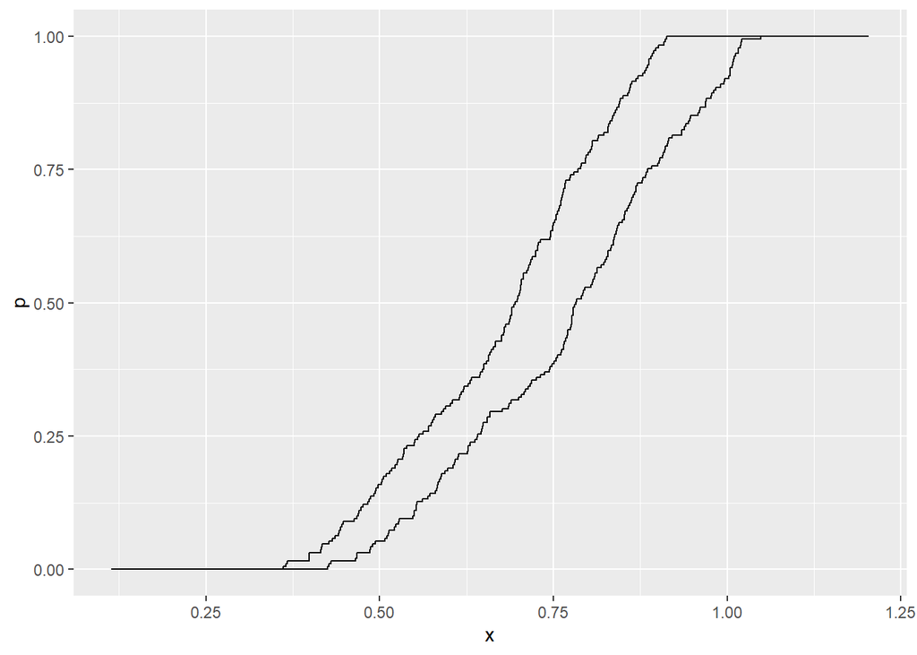

```r
cuantilBorroso <- function(delta, numeros) {
  N <- length(numeros)
  Ls <- c()
  Rs <- c()
  result <- data.frame(x_L = NA,
                       x_R = NA,
                       p = sort(rep(seq(from = 0, to = 1, by = 1/N), 2)))
  for(num in numeros) {
    cuts <- alphacut(num, delta)
    Ls <- c(Ls, cuts[1])
    Rs <- c(Rs, cuts[2])
  }
  result$x_L <- sort(c(rep(Ls, 2),
                       min(Ls) - (max(Ls) - min(Ls)) / 4,
                       max(Ls) + (max(Ls) - min(Ls)) / 2))
  result$x_R <- sort(c(rep(Rs, 2),
                       min(Rs) - (max(Rs) - min(Rs)) / 2,
                       max(Rs) + (max(Rs) - min(Rs)) / 4))
  plot <- ggplot(result) +
    geom_path(aes(x = x_L, y = p)) +
    geom_path(aes(x = x_R, y = p)) +
    xlab("x")
  return(list(plot = plot, result = result))
}

cuantilBorroso(0.25, fuzzyIDH)$plot
```

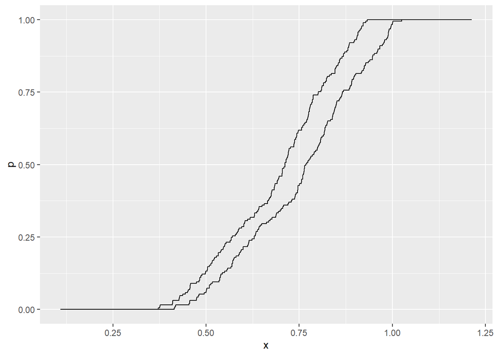

```r
cuantilBorroso(0.5, fuzzyIDH)$plot
```

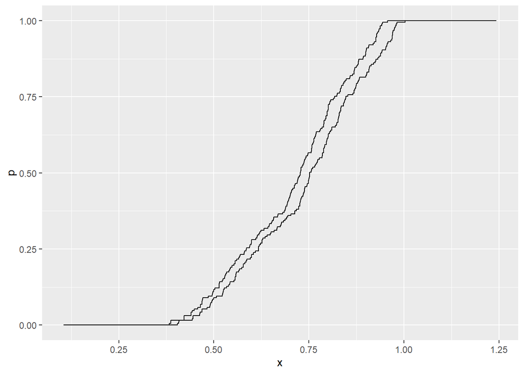

```r
cuantilBorroso(0.75, fuzzyIDH)$plot
```

## Mediana

```r
knotL <- c()
knotR <- c()
nCuts <- 50
delta <- seq(1/(nCuts + 1), 1 - 1/(nCuts + 1), 1/(nCuts + 1))
for(cut in delta) {
  knotL <- c(knotL, filter(cuantilBorroso(cut, fuzzyIDH)$result, p > 0.5)[1,1])
  knotR <- c(knotR, filter(cuantilBorroso(cut, fuzzyIDH)$result, p > 0.5)[1,2])
}
core <- filter(cuantilBorroso(1, fuzzyIDH)$result, p > 0.5)[1,1]
support <- filter(cuantilBorroso(0, fuzzyIDH)$result, p > 0.5)[1,1:2]

medianFuzzy <- PiecewiseLinearFuzzyNumber(support[,1],
                                          core,
                                          core,
                                          support[,2],
                                          knot.n = nCuts,
                                          knot.alpha = delta,
                                          knot.left = knotL,
                                          knot.right = sort(knotR))
medianFuzzy
```

```
## Piecewise linear fuzzy number with 50 knot(s),
##    support=[0.678467,0.797395],
##       core=[0.739728,0.739728].
```

```r
distancia <- c()
for(pais in 1:nrow(data)) {
  distancia[pais] <- distance(medianFuzzy, fuzzyIDH[[pais]])
}

which(distancia %in% sort(distancia)[1:5])
```

```
## [1]  93  95  98  99 100
```

```r
data[c(93,95,98,99,100),1]
```

| Country |
| --- |
| Fiji |
| Maldives |
| Suriname |
| Mongolia |
| Botswana |

```r
medianCrisp <- median(data$IDH)

data %>%
  mutate(distancia = abs(IDH - medianCrisp)) %>%
  top_n(5, -distancia)
```

| Country | Life expectancy at birth | Expected years of schooling | Mean years of schooling | Gross national income per capita | Population | indexHealth | indexEducation1 | indexEducation2 | indexEducation | indexGNI | IDH | fuzzyPop | distancia |
| --- | --- | --- | --- | --- | --- | --- | --- | --- | --- | --- | --- | --- | --- |
| Dominica | 78.21 | 12.96618 | 8.142186 | 11883.96 | 71808 | 0.8955385 | 0.7203433 | 0.5428124 | 0.6315778 | 0.7217102 | 0.7418077 | 0.06228452 | 0.0020801565 |
| Maldives | 78.92 | 12.20000 | 7.020278 | 17416.78 | 530953 | 0.9064615 | 0.6777778 | 0.4680185 | 0.5728982 | 0.7794505 | 0.7397275 | 0.08005327 | 0.0000000000 |
| Tunisia | 76.70 | 15.12561 | 7.220220 | 10414.06 | 11694719 | 0.8723077 | 0.8403117 | 0.4813480 | 0.6608298 | 0.7017660 | 0.7395778 | 0.10751639 | 0.0001496796 |
| Saint Vincent and the Grenadines | 72.53 | 14.09404 | 8.784648 | 12377.65 | 110589 | 0.8081538 | 0.7830022 | 0.5856432 | 0.6843227 | 0.7278587 | 0.7383586 | 0.06611971 | 0.0013688818 |
| Suriname | 71.68 | 13.18803 | 9.261387 | 14324.38 | 581363 | 0.7950769 | 0.7326682 | 0.6174258 | 0.6750470 | 0.7499234 | 0.7383348 | 0.08085882 | 0.0013926793 |

## Promedio

```r
suma_idh <- fuzzyIDH[[1]]
for (i in 2:length(fuzzyIDH)) {
  suma_idh <- suma_idh + fuzzyIDH[[i]]
}

idh_promedio <- suma_idh/length(fuzzyIDH)
idh_promedio
```

```
## Piecewise linear fuzzy number with 0 knot(s),
##    support=[0.658103,0.786108],
##       core=[0.723312,0.723312].
```

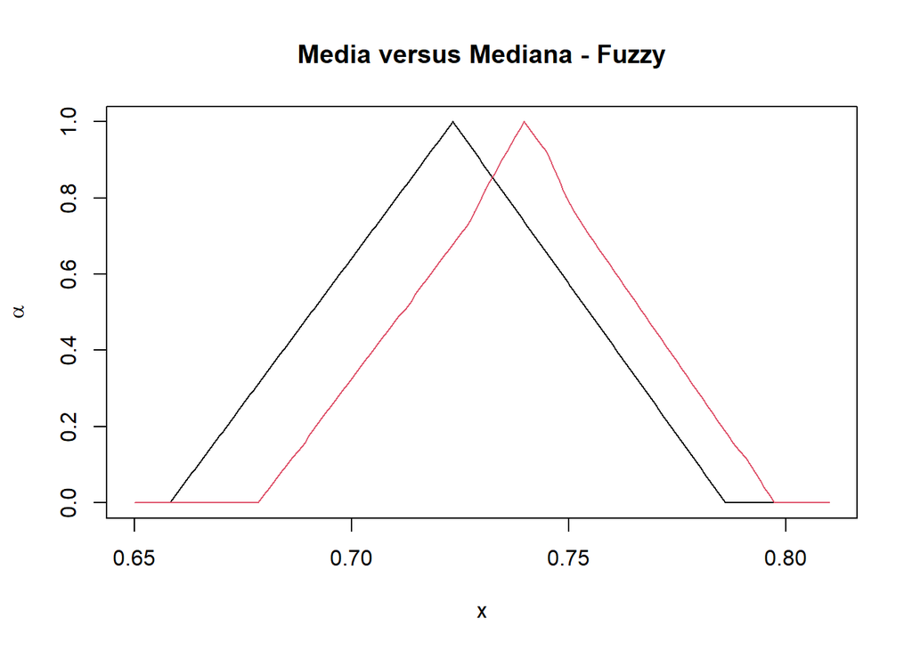

```r
plot(idh_promedio, col = 1, main = "Media versus Mediana - Fuzzy", xlim = c(0.65, 0.81))
plot(medianFuzzy, col = 2, add = TRUE)
```

Comparando la mediana con la media, se observa que la mediana es mayor a la media, es decir, la distribución está sesgada a la izquierda, lo cual indica que existen una mayor cantidad de países con un IDH superior a la media con respecto a los que se encuentran por debajo de la misma.

## Frecuencia Relativa Borrosa

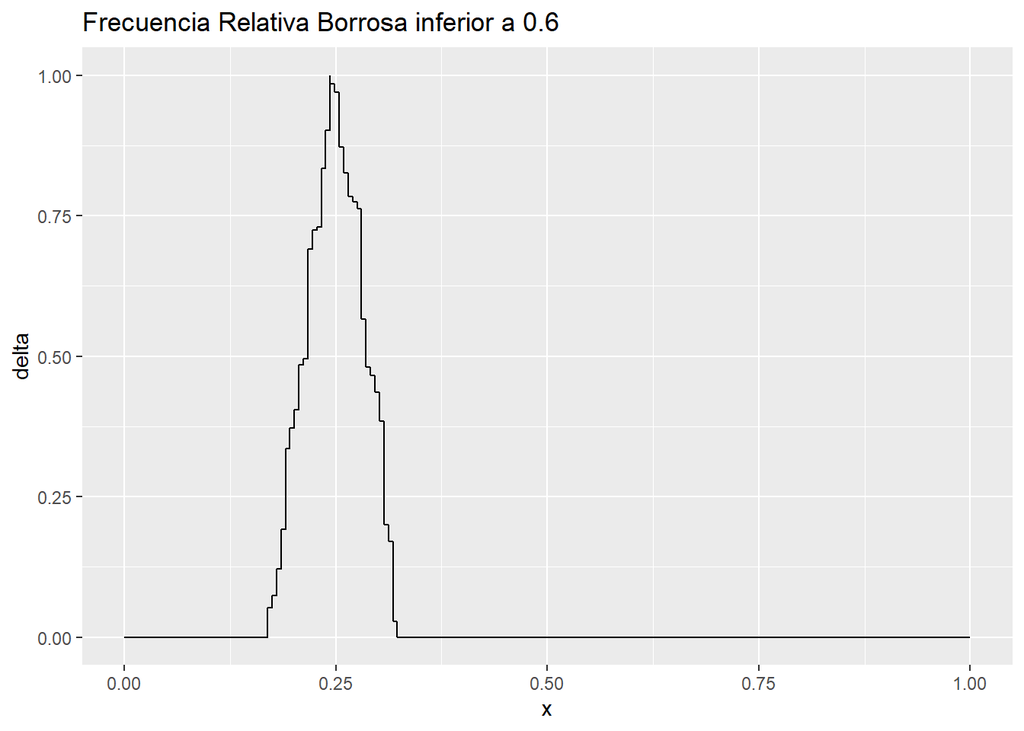

```r
# funion para obtener la frecuencia relativa borrosa
interseccion <- function(clase, corte) {
  if((corte[1] >= clase[1] & corte[1] <= clase[2]) |
     (corte[2] >= clase[1] & corte[2] <= clase[2])) {
    return (TRUE)
  } else {
    return (FALSE)
  }
}
contenido <- function(clase, corte) {
  if(corte[1] >= clase[1] & corte[2] <= clase[2]) {
    return (TRUE)
  } else {
    return (FALSE)
  }
}
frecRelBorrosa <- function(clase, numeros, pasos = 500) {
  N <- length(numeros)
  knots <- data.frame()
  for(paso in 1:pasos) { # para cada paso...
    delta <- paso / pasos # sacamos el delta
    nIntersect <- 0
    nContenido <- 0
    for(num in numeros) { # para cada numero borroso...
      corte <- alphacut(num, delta) # sacamos el delta-corte
      if(interseccion(clase, corte)) { # contamos si el corte interseca la clase
        nIntersect <- nIntersect + 1
      }
      if(contenido(clase, corte)) { # contamos si el corte esta contenido en la clase
        nContenido <- nContenido + 1
      }
    }
    knots <- rbind(knots, c(delta, nContenido / N, nIntersect / N))
  }
  names(knots) <- c("delta", "L", "R")
  Ls <- knots %>%
    select(-R) %>%
    group_by(L) %>%
    summarise(maxdelta = max(delta)) %>%
    ungroup()
  Rs <- knots %>%
    select(-L) %>%
    group_by(R) %>%
    summarise(maxdelta = max(delta)) %>%
    ungroup()
  x <- sort(c(0, 1, rep(Ls$L, 2), rep(Rs$R, 2)))
  y <- c(0, 0,
         sort(rep(Ls$maxdelta, 2)),
         sort(rep(Rs$maxdelta[-1], 2), decreasing = T),
         0, 0)
  result <- data.frame(x = x, delta = y)
  plot <- ggplot(result) +
    geom_path(mapping = aes(x = x, y = delta))
  return(plot)
}

frecRelBorrosa(c(0, 0.6), fuzzyIDH) +
  ggtitle("Frecuencia Relativa Borrosa inferior a 0.6")
```

Se puede considerar que un valor del IDH inferior a 0.6 es bajo. En el gráfico podemos observar como aproximadamente 1 de cada 4 países tiene un IDH bajo. Con valores de delta bajos, un 20% de los países tienen un valor bajo con total seguridad, mientras que hasta un 30% de los países podría tener un valor bajo.